# Are they discussing the same thing?

[figure not shown]

## The basic data set for this project is called philosophy data set, which is from Kaggle. This data set concludes text from different philosophers who belong to various schools of philosophy. My project is based on one of this school: feminism. Therefore, I conduct my data analysis based on subsets of this data set.

## Clean the data

Firstly, in order to have a better understanding of data in feminism, I transform the raw data as pandas dataframe to get the subsets of data set and clean these subsets of data. To clean the data, I create a function to help me delete the punctuations and stop words in the text.

```python
# Here are the packages I use for my project
import pandas as pd
import numpy as np
import matplotlib.pyplot as plt
from wordcloud import WordCloud
import seaborn as sns
import string
import nltk
from nltk.corpus import stopwords
from sklearn.feature_extraction.text import CountVectorizer
from sklearn.feature_extraction.text import TfidfTransformer
from nrclex import NRCLex
```

```python
df=pd.read_csv('philosophy_data.csv')
fe=df[df['school']=='feminism'].reset_index()
fe['author'].unique()#check how many different author in this feminism data set
```

```
array(['Wollstonecraft', 'Beauvoir', 'Davis'], dtype=object)
```

```python
davis=fe[fe['author']=='Davis'].reset_index()
wol=fe[fe['author']=='Wollstonecraft'].reset_index()
bea=fe[fe['author']=='Beauvoir'].reset_index()
```

```python
def text_clean(sen):
    nopunc=[word for word in sen if word not in string.punctuation]
    nopunc=''.join(nopunc)
    return [word for word in nopunc.split() if word not in stopwords.words('english')]
#I create a function to help me delete the punctuation and stopwords in the text. This function can also split
#the sentences into lists of words to analyze.
```

```python
davis['clean_sentence']=davis['sentence_lowered'].apply(text_clean)
wol['clean_sentence']=wol['sentence_lowered'].apply(text_clean)
bea['clean_sentence']=bea['sentence_lowered'].apply(text_clean)
```

```python
davis.describe()
```

|  | level_0 | index | original_publication_date | corpus_edition_date | sentence_length |
| --- | --- | --- | --- | --- | --- |
| count | 3059.000000 | 3059.000000 | 3059.0 | 3059.0 | 3059.000000 |
| mean | 17105.000000 | 359278.000000 | 1981.0 | 1981.0 | 139.671134 |
| std | 883.201562 | 883.201562 | 0.0 | 0.0 | 71.069447 |
| min | 15576.000000 | 357749.000000 | 1981.0 | 1981.0 | 20.000000 |
| 25% | 16340.500000 | 358513.500000 | 1981.0 | 1981.0 | 92.000000 |
| 50% | 17105.000000 | 359278.000000 | 1981.0 | 1981.0 | 133.000000 |
| 75% | 17869.500000 | 360042.500000 | 1981.0 | 1981.0 | 176.000000 |
| max | 18634.000000 | 360807.000000 | 1981.0 | 1981.0 | 731.000000 |

```python
wol.describe()
```

|  | level_0 | index | original_publication_date | corpus_edition_date | sentence_length |
| --- | --- | --- | --- | --- | --- |
| count | 2559.000000 | 2559.000000 | 2559.0 | 2559.0 | 2559.000000 |
| mean | 1279.000000 | 343452.000000 | 1792.0 | 2001.0 | 190.957796 |
| std | 738.863993 | 738.863993 | 0.0 | 0.0 | 109.556494 |
| min | 0.000000 | 342173.000000 | 1792.0 | 2001.0 | 20.000000 |
| 25% | 639.500000 | 342812.500000 | 1792.0 | 2001.0 | 109.000000 |
| 50% | 1279.000000 | 343452.000000 | 1792.0 | 2001.0 | 173.000000 |
| 75% | 1918.500000 | 344091.500000 | 1792.0 | 2001.0 | 256.000000 |
| max | 2558.000000 | 344731.000000 | 1792.0 | 2001.0 | 804.000000 |

```python
bea.describe()
```

|  | level_0 | index | original_publication_date | corpus_edition_date | sentence_length |
| --- | --- | --- | --- | --- | --- |
| count | 13017.000000 | 13017.000000 | 13017.0 | 13017.0 | 13017.000000 |
| mean | 9067.000000 | 351240.000000 | 1949.0 | 2009.0 | 148.790351 |
| std | 3757.828562 | 3757.828562 | 0.0 | 0.0 | 112.953314 |
| min | 2559.000000 | 344732.000000 | 1949.0 | 2009.0 | 20.000000 |
| 25% | 5813.000000 | 347986.000000 | 1949.0 | 2009.0 | 70.000000 |
| 50% | 9067.000000 | 351240.000000 | 1949.0 | 2009.0 | 118.000000 |
| 75% | 12321.000000 | 354494.000000 | 1949.0 | 2009.0 | 192.000000 |
| max | 15575.000000 | 357748.000000 | 1949.0 | 2009.0 | 1301.000000 |

After cleaning the dataset, we can see there are three different authors from feminism:'Wollstonecraft', 'Beauvoir', and 'Davis'. According to the data description above, we can know the original publication dates of 'Wollstonecraft'and 'Davis' vary the most. Therefore, I decide to analyze their text to see the differences in their text. Even though they are all under the school of feminism, their thoughts may vary due to the different periods and their different living environment.

## Q1: are they writing in a similar way?

Since these three authors coming from different periods, their text may have different format, like length. So I use bar plot to visualize the lenth of text, see if there's any significant difference.

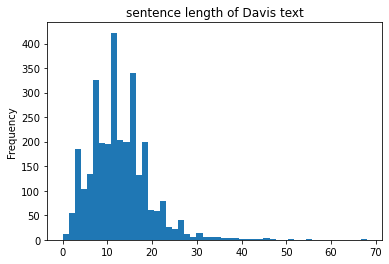

```python
davis['length'] = davis['clean_sentence'].apply(len)
davis['length'].plot(bins=50, kind='hist',title='sentence length of Davis text')
```

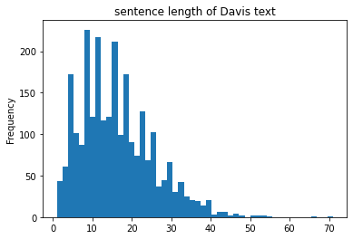

```python
wol['length'] = wol['clean_sentence'].apply(len)
wol['length'].plot(bins=50, kind='hist',title='sentence length of Davis text')
```

## Q2: are they dicussing the same topic?

One way to analyze the topic is to check the words their use most in their text. I use the word cloud to have a more direct and clear observation on the words.

### Word cloud

Word cloud from Davis data set

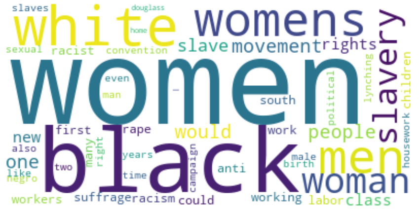

```python
bow_transformer0 = CountVectorizer(analyzer=text_clean).fit(davis['sentence_lowered'])
davis_bow = bow_transformer0.transform(davis['sentence_lowered'])
features_names0=bow_transformer0.get_feature_names_out()
tfidf_transformer0 = TfidfTransformer().fit(davis_bow)
davis_tfidf = tfidf_transformer0.transform(davis_bow)
dense =davis_tfidf .todense()
denselist = dense.tolist()
df_davis_1 = pd.DataFrame(denselist, columns=features_names0)
#df_davis_1.T.sum(axis=1)
Cloud = WordCloud(background_color="white", max_words=50).generate_from_frequencies(df_davis_1.T.sum(axis=1))
plt.figure( figsize=(15,10))
plt.axis("off")
plt.imshow(Cloud,interpolation='bilinear')
```

Word cloud from Wollstonecraft data set

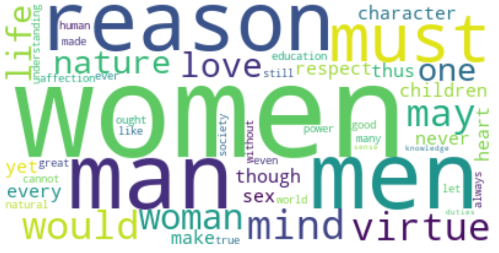

```python
bow_transformer1 = CountVectorizer(analyzer=text_clean).fit(wol['sentence_lowered'])
wol_bow = bow_transformer1.transform(wol['sentence_lowered'])
features_names1=bow_transformer1.get_feature_names_out()
tfidf_transformer1 = TfidfTransformer().fit(wol_bow)
wol_tfidf = tfidf_transformer1.transform(wol_bow)
dense =wol_tfidf .todense()
denselist = dense.tolist()
df_wol = pd.DataFrame(denselist, columns=features_names1)
#df_davis_1.T.sum(axis=1)
Cloud = WordCloud(background_color="white", max_words=50).generate_from_frequencies(df_wol.T.sum(axis=1))
plt.figure( figsize=(15,10))
plt.axis("off")
plt.imshow(Cloud,interpolation='bilinear')
```

In both word clouds, the most frequent word is 'women'. This is obvious since both of the authors are feminism. There are slight difference we can see from these word clouds. In Davis word cloud, the words 'black' and 'white' mentioned a lot. Therefore, we can infer that Davis text is more focusing on black women and inequalities in society that black women face. The topic related to racist is a significant one in her text. While in Wollstonecraft's word cloud, she seems more focus on the topic of women themselves since the words 'mind','reason', and 'virture' mentioned a lot in her text. Thus, the words these two authors in their text are quite different, which infer the differences in their topics.

Let's go deeper in these words. Since the topics of these text are quite different, the emotions that these words deliver may also vary. Next we can analyse the emotions to check the differences.

### emotional analysis

```python
from nrclex import NRCLex
```

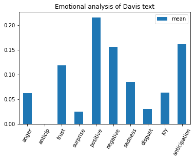

```python
#I use the NRCLex package to help me do the emotional analysis with words
davis['emotions']=davis['sentence_lowered'].apply(lambda x: NRCLex(x).affect_frequencies)
df=pd.concat([davis.drop(['emotions'],axis=1),davis['emotions'].apply(pd.Series)],axis=1)
df_davis=df.describe()
df_davis1=pd.DataFrame(df_davis.iloc[1,7:])
df_davis1.plot.bar(rot=60,title='Emotional analysis of Davis text')
```

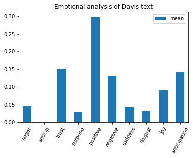

```python
wol['emotions']=wol['sentence_lowered'].apply(lambda x: NRCLex(x).affect_frequencies)
df=pd.concat([wol.drop(['emotions'],axis=1),wol['emotions'].apply(pd.Series)],axis=1)
df_wol=df.describe()
df_wol1=pd.DataFrame(df_wol.iloc[1,7:])
df_wol1.plot.bar(rot=60,title='Emotional analysis of Davis text')
```

According to the bar plots above, the distribution of the emotions are quite similar in this two text. Both text deliver the positive emotions most. But Davis seems more likely to deliver negative emotions. I think this is reasonable, because Davis is more focusing on the society issue. Her dicussion of feminism is based on the painful history of black women. Her story of feminism is heavy. Wollstonecraft encouraged women to accept education, so her words have less negative emotions but more positive emotions.

## Conclusion

In conclusion, although these two authors are all from feminism, they still hold different points of views based on their period of time. Because Davis is a modern philosopher and from minority group, her points of view is not only focusing on all women but a minority group of women. She discovered that inequality doens't exist only bewteen men and women, but also exist among women from different colors. Wollstonecraft lived in a much early period. In her period, women just relealized the inequality between themselves and men and the feminism wasn't a very mature school of philosophy. Therefore, Wollstonecraft encouraged women to fight for their rights. Her articles are more focusing on the general idea of women's rights. Even these two femenists are focusing on different ideas, the foundations of their text are the same: women's rights.